# Diagrams

# Meiosis Visual

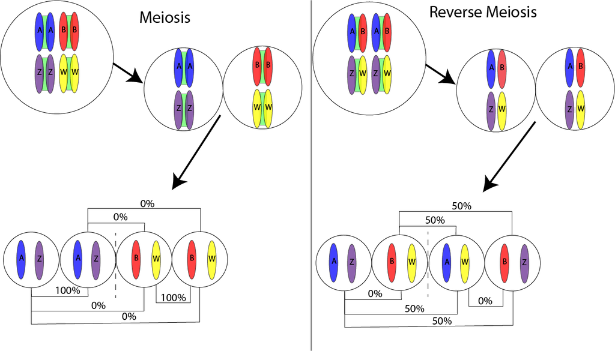

Sources: Bogdanov (2016), Boman et al. (2024), Cabral et al. (2014), and Li and He (n.d.)

# Mosaic vs. Chimera Visual

This diagram is in response to questions about if both mosaicism and chimerism could lead to gynandromorphism, and why we believe that it is more probably one than the other. The diagrams show the mechanisms of both mosaicism and chimerism, showing that mosaicism is the result of a nondisjunction event while chimerism results from the merging of seperate zygotes. The final pictures show that both mechanisms can result in either a gynandromorph or an individual of one sex, as well as the phenotypic and genotypic bases for favouring one mechanism to another. Phenotypically, it should make sense that the first guess for mechanism based upon having a bilateral gynandromorph would be chimerism due to the merging nature. We can then test that by looking to see if the two sides have two distinct genomes or whether they have one genome with an alteration.

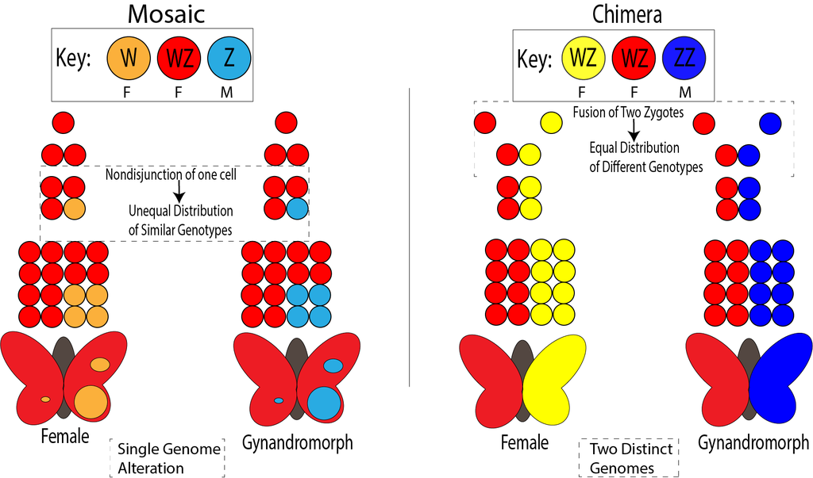

Sources: Conlin et al. (2010), Fusco and Minelli (2023), and Sahara, Yoshido, and Traut (2012)

Bogdanov, Yu F. 2016. “[Inverted Meiosis and Its Place in the Evolution of Sexual Reproduction Pathways].” *Genetika* 52 (May): 541–60. https://doi.org/10.7868/s0016675816050039.

Boman, Jesper, Christer Wiklund, Roger Vila, and Niclas Backström. 2024. “Meiotic Drive Against Chromosome Fusions in Butterfly Hybrids.” *Chromosome Res* 1: 7. https://doi.org/10.1007/s10577-024-09752-0.

Cabral, Gabriela, André Marques, Veit Schubert, Andrea Pedrosa-Harand, Peter Schlögelhofer, and Nelson Chaves. 2014. “ARTICLE Chiasmatic and Achiasmatic Inverted Meiosis of Plants with Holocentric Chromosomes.” https://doi.org/10.1038/ncomms6070.

Conlin, Laura K, Brian D Thiel, Carsten G Bonnemann, Livija Medne, Linda M Ernst, Elaine H Zackai, Matthew A Deardorff, Ian D Krantz, Hakon Hakonarson, and Nancy B Spinner. 2010. “Mechanisms of Mosaicism, Chimerism and Uniparental Disomy Identified by Single Nucleotide Polymorphism Array Analysis.” https://doi.org/10.1093/hmg/ddq003.

Fusco, Giuseppe, and Alessandro Minelli. 2023. “Descriptive Versus Causal Morphology: Gynandromorphism and Intersexuality.” *Theory in Biosciences* 142 (February): 1–11. https://doi.org/10.1007/s12064-023-00385-1.

Li, Wenzhu, and Xiangwei He. n.d. “Inverted Meiosis: An Alternative Way of Chromosome Segregation for Reproduction.” *Acta Biochim Biophys Sin* 2020: 702–7. https://doi.org/10.1093/abbs/gmaa054.

Sahara, Ken, Atsuo Yoshido, and Walther Traut. 2012. “Sex Chromosome Evolution in Moths and Butterflies.” *Chromosome Research : An International Journal on the Molecular, Supramolecular and Evolutionary Aspects of Chromosome Biology* 20 (January): 83–94. https://doi.org/10.1007/S10577-011-9262-Z.